# open_questions

Question 2: Model Performance and Error Analysis

The most frequently misclassified classes were Neutral and positive. For LSTM, 73 positive samples were predicted as neutral while 44 neutral samples were predicted as positive. for the mlp the confusion was even more pronounced with 82 neutral samples misclassified as positive. Reasons for this may be that financial language could contain subtle sentiment cues where posiive statements that are mild can resemble neutral case. The overlap between these categories makes them more difficult to tell compared to negative statements.

Question 3: Cross-Model Comparison

Out of all the models, BERT had the highest accruacy at about 80.5 percent, GRU at 76.8 percent, and LSTM at 75 percent, GPT at around 74 percent,and MLP and RNN at the lowest about 71 percent. The MLP relied on mean pooled FastText embeddings which loses sequential and context information which makes it harder to capture the compoisitional meaning. However, sequence based models process the tokens in order which allow them to model the relationships and dependencies between words. This shows why MLP's lower performance result happened compared to the transformer based models.

The LSTM sequential processing helps capture long range dependencies through gating mechanisms. It also allows it to retain contextual information across the sentence, unlike the MLP which treats the input as an average of embeddings. The gated structure helps deal with vanishing gradients and learn better the patterns and sentiment cues.

The ranking for RNN was worst most likely due to the challenge of modeling long range dependences. MLP slightly did better than RNN but lacked the sequential modeling. LSTM and GRU improved performance by modeling the sequential dependences and also solving the problem fo vanishing gradients. GPT also benefited from transformer based pretraining but could be llimited by the autoregressive nature of the architecture. BERT did the best due to most likely the bidirectional context representations and large scale pretraining, capturing more nuanced patterns.

BERT Confusion Matrix

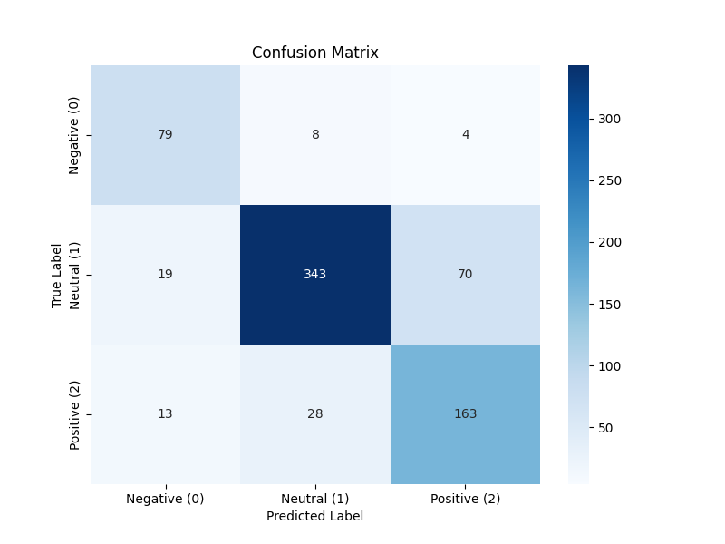

GPT Confusion Matrix

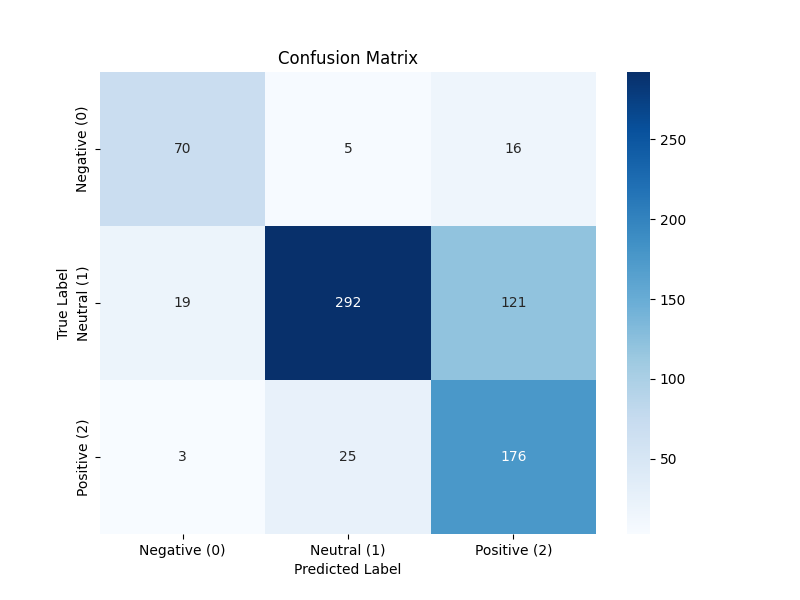

GRU Confusion Matrix

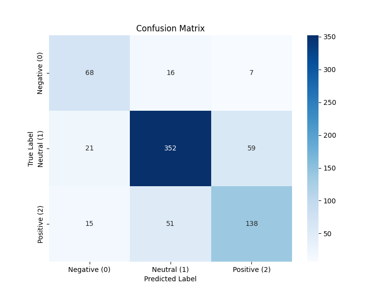

RNN Confusion Matrix

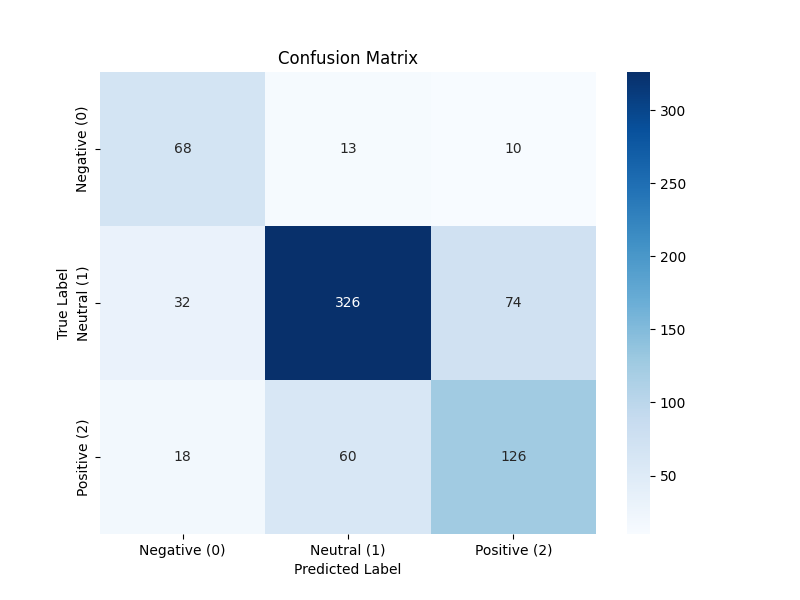

LSTM Confusion Matrix

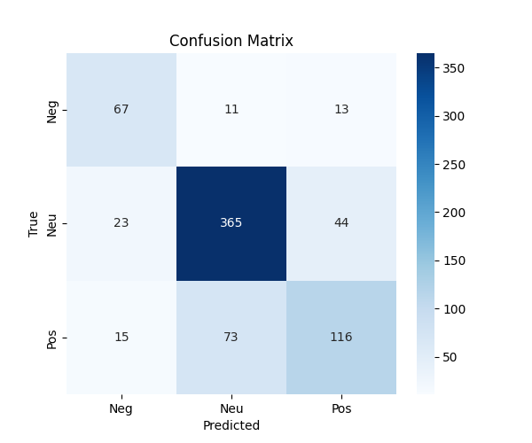

MLP Confusion Matrix

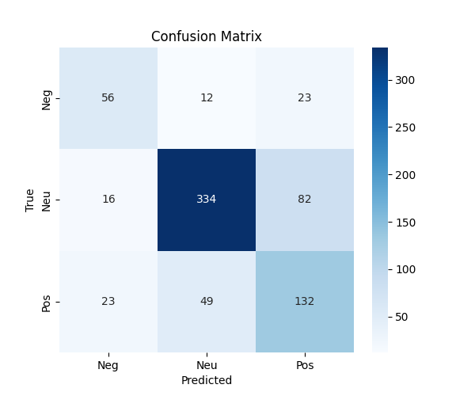

```python
from IPython.display import Image, display, Markdown

models = {
    "BERT Confusion Matrix": "outputs/bert_confusion_matrix.png",
    "GPT Confusion Matrix": "outputs/gpt_confusion_matrix.png",
    "GRU Confusion Matrix": "outputs/gru_confusion_matrix.png",
    "RNN Confusion Matrix": "outputs/rnn_confusion_matrix.png",
    "LSTM Confusion Matrix": "outputs/lstm_confusion_matrix.png",
    "MLP Confusion Matrix": "outputs/mlp_confusion_matrix.png"
}

for title, path in models.items():
    display(Markdown(f"## {title}"))
    display(Image(filename=path, width=500))
```

## AI Use Disclosure (Required)

If you used any AI-enabled tools (e.g., ChatGPT, GitHub Copilot, Claude, or other LLM assistants) while working on this assignment, you must disclose that use here. The goal is transparency-not punishment.

In your disclosure, briefly include:

- **Tool(s) used:** (name + version if known)
- **How you used them:** (e.g., concept explanation, debugging, drafting code, rewriting text)
- **What you verified yourself:** (e.g., reran the notebook, checked outputs/plots, checked shapes, read documentation)
- **What you did *not* use AI for (if applicable):** (optional)

You are responsible for the correctness of your submission, even if AI suggested code or explanations.

#### Write your disclosure here.

#### I used Chatgpt the 5.2 free version. I used Chatgpt to walk me through a lot of the hints/instructions in order to come up with the code for the classifiers. I verified myself the code that I got from Chatgpt through going through line by line and understanding what was being done, and I also was the one who interpreted the graphs, but had Chatgpt explain how might different factors influence the graphs looking the way that it did.